# The 2019-20 NBA Season: What Could Have Been

Ryan Kohanski

Rithvik Saravanan

Howard Yong

May 11, 2020

# Abstract

# Introduction

Due to the widespread impact of the COVID-19 pandemic throughout the world, almost every company, organization, and public event has canceled or suspended any activities that involve interpersonal contact for the forseeable future. Many of these activities are moving to a virtual format if possible, but several others have been forced to shut down.

As avid sports fans, the absence of the major sporting events during this time has hit us and many others around the world especially hard [1]. Some of the events that we particularly were looking forward to include the NBA, NCAA March Madness tournament, MLB, and the 2020 Summer Olympics.

In our curiosity, we decided to utilize this opportunity to exercise our data science and modeling skills in order to predict what could have been. Specifically, we focused on the NBA and the NBA Playoffs. Since the 2019-20 NBA season was suspended approximately one month prior to the end of the regular season (and the beginning of the Playoffs), we used the 2019-20 season data accumulated from the games played before the suspension to predict how the season and the Playoffs would have ended had everything gone according to schedule.

In this analysis, we will examine data from the 2019-20 NBA season as well as some data from previous NBA seasons in order to draw some meaningful conclusions about the remainder of the 2019-20 NBA season including the final season standings, playoff matchups, championship winner, and season award winners.

# Methods

## Predicting the 2019-20 NBA Season Standings

Since we missed one of the most exciting times of the year (the NBA Playoffs & Finals), we made some predictions on how the rest of the season might have played out using a popular methodology referred to as the Elo ratings system [2]. This tool, created by Hungarian-American physics professor Arpad Elo, was orginally designed to rate chess players, but is now used for all sorts of competitions ranging anywhere from sports to video games. This is a methodology that FiveThirtyEight and many other popular sports analysts take advantage of due to its simplicity and effectiveness [3].

These ratings depend only on the final score of each game as well as where it was played (home-court advantage). In other words, this system is built on a Win/Loss basis. We will be analyzing the 2018-19 NBA Season in its entirety to validate its performance, then we will apply it to the 2019-20 regular season in order to predict the matchups for the Playoffs and the Finals and ultimately the NBA Champions. For this project, we retrieved several types of data sources including game-by-game scores and schedules for several seasons from Basketball-Reference.com [4].

### How does Elo work?

The long-run average for an Elo score in the NBA sits around 1500. An Elo of 1500 means that the teams performance would be normally distrubuted around an average of 1500 with the chance of performing better or worse. For more detail, Figure (Appendix) shows what an Elo rating tells us about a team and how it can convey the teams overall season record. A higher Elo rating indicates that the team has a high win-loss ratio and is more likely to play deeper into the season.

The formula for Elo below shows how the probability of one team beating another is calculated using the ratings. When Player $A$ competes in a match against Player $B$, Player $A$ has an expected outcome (probability or score) for Team $A$ ($E[A]$) where $R_A$ is the rating for Team $A$ and $R_B$ is the rating for Team $B$. The expected outcome for Team $A$ ($E[A]$) can be calculated by the formula below:

$$E[A] = \frac{1}{1 + 10^{\frac{(R_B-R_A)}{400}}}$$

The same calculation ($E[B]$) has to be done for Player $B$, but with $R_A$ (current rating $A$) and $R_B$ (current rating $B$) swapped so that $E[A] + E[B] = 1$. Once the match is played and $S_A$ (actual outcome or score for Team $A$) and $S_B$ (actual outcome or score for Team $B$) are determined, $R^{\prime}_A$ (the new rating for $A$) and $R^{\prime}_B$ (the new rating for $A$) are calculated with the formula below:

$$R^{\prime}_A=R_A+K(S_A-E[A])$$

The $S$ value in our case would either be 1 for a win, or 0 for a loss. This is because there are no ties in the NBA.

In this equation, $K$ is an optimization constant that usually takes different values according the sport and the amount of games available. In other words, this value is the maximum amount by which a score can change in one match. If $K$ is set too high, the ratings will jump around too much; if $K$ is set too low, Elo will take too long to recognize important changes in team quality. Determining the right value of K is an entirely different and more complicated topic, so for this experiment we will be using $K=20$, the optimal $K$ for the NBA determined by FiveThirtyEight [3]. This is higher than most other sports and can likely be attributed to the fact that the NBA plays more games (81 games per team) and is subject to relatively little randomness.

Home-court advantage is set as equivalent to 100 Elo rating points. One hundred Elo points is equivalent to about 3.5 NBA points, so it can also be interpreted as the home team being favored by 3 to 4 points if the teams were otherwise evenly matched (obviously this value fluctuates from season to season). Since every team plays about half of their games at home and the other half away, a change in the home-court advantage value does not produce a significant difference in the ratings, but is still an important factor to consider.

Elo strikes a nice balance between ratings systems that account for margin of victory and those that do not. While teams always gain Elo points after wins and lose Elo points after losses, they also gain or lose more with larger margins of victory.

Since this is a consistent method, we will also initialize the Elo scores for the 2019-20 NBA Season using the Elo scores from the 2018-19 season.

After incorporating a constant for home court advantage, our formula is as follows with $A=100$ points (the value we previously determined represents a home-court advantage):

$$P(\mbox{Home team wins}) = \frac{1}{1 + 10^{-\frac{(H-R+A)}{400}}}$$

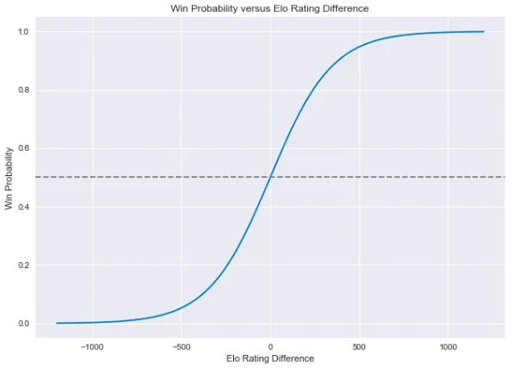

Logistic Function of Win Probability by Elo Rating Difference

### Calculating Elo Ratings

For our project scope, we decided to model our Elo rating system purely off of home court advantage, wins, losses, and point margin differentials. Of course, in the NBA, there is a wide array of different factors to consider, including roster changes, injuries, winning streaks, etc. These are all features that limit the capabilities of our model, but serve as potential targets of investigation for the future. As we mentioned before, one principal task of our project was to explore outcomes of the 2019-20 NBA season if they were to continue. In order to do so, we first needed to develop Elo ratings for each team at their current state of the 2019-20 season. Online resources report that the NBA has historically shown an average Elo rating of 1505, as the league is continually experiencing expansions and contractions that influence the center of the distribution of team ratings. We followed this statistic in our Elo rating calculations. When simulating Elo rating calculations for each team throughout multiple seasons, we preemptively decided to carry over 75% of each team’s Elo rating from the previous season, with the other 25% weight carried by the league average of 1505. This proportion was determined through historical league analyses of the NBA.

For the scope of our analysis, we decided to begin our analysis in the 2016-17 NBA season. We chose to start our calculations from this season because the season data was readily available and provided enough years to build a more-updated status of each team’s current standing in the league. We started by scraping online sources for box score statistics for each team. Our source for basketball statistics for Elo rating calculations came from basketball-reference. Once we scraped and processed the data, we exported them into indepdent .csv files for each season. Below is an example of data from the 2019-20 NBA season we collected.

|  | game_id | date_game | game_start_time | visitor_team_name | visitor_pts | home_team_name | home_pts | overtimes | attendance | game_remarks | home_team_wins |
| --- | --- | --- | --- | --- | --- | --- | --- | --- | --- | --- | --- |
| 1 | 201910220TOR | 2019-10-22 | 8:00p | New Orleans Pelicans | 122 | Toronto Raptors | 130 | OT | 20787 |  | 1 |
| 2 | 201910220LAC | 2019-10-22 | 10:30p | Los Angeles Lakers | 102 | Los Angeles Clippers | 112 |  | 19068 |  | 1 |
| 3 | 201910230CHO | 2019-10-23 | 7:00p | Chicago Bulls | 125 | Charlotte Hornets | 126 |  | 15424 |  | 1 |
| 4 | 201910230IND | 2019-10-23 | 7:00p | Detroit Pistons | 119 | Indiana Pacers | 110 |  | 17923 |  | 0 |
| 5 | 201910230ORL | 2019-10-23 | 7:00p | Cleveland Cavaliers | 85 | Orlando Magic | 94 |  | 18846 |  | 1 |
| 6 | 201910230BRK | 2019-10-23 | 7:30p | Minnesota Timberwolves | 127 | Brooklyn Nets | 126 | OT | 17732 |  | 0 |

Once we had all the data collected for the season, we calculated the Elo ratings by the same methods previously mentioned. We iterated through the season by each matchup, calculating and updating the Elo ratings for the teams playing simultaneously, and applied this to every season until 2019-20.

Below is an example of what the teams Elo ratings looked like at the end of the 2016-2017 season, the year that Kevin Durant made the controversial move to the Golden State Warriors and took them on a championship run.

| team | elo |
| --- | --- |
| Golden State Warriors | 1834.8023 |
| San Antonio Spurs | 1641.0866 |
| Cleveland Cavaliers | 1637.0718 |
| Houston Rockets | 1613.1483 |
| Utah Jazz | 1595.1288 |
| Los Angeles Clippers | 1590.3924 |
| Boston Celtics | 1589.2328 |
| Washington Wizards | 1578.5608 |
| Toronto Raptors | 1557.6831 |
| Miami Heat | 1551.7687 |

[output cut: 20 more lines]

After our calculations, we were obtain the Elo ratings of the NBA teams at the beginning of the 2019-20 season. We tracked their progress throughout this year’s season and plotted them in the figure below. The plot is facetted by conferences, which determines how many times a team plays other teams, as well as who they may contend against in their playoff runs. The current Elo ratings of each team in the league can be found below.

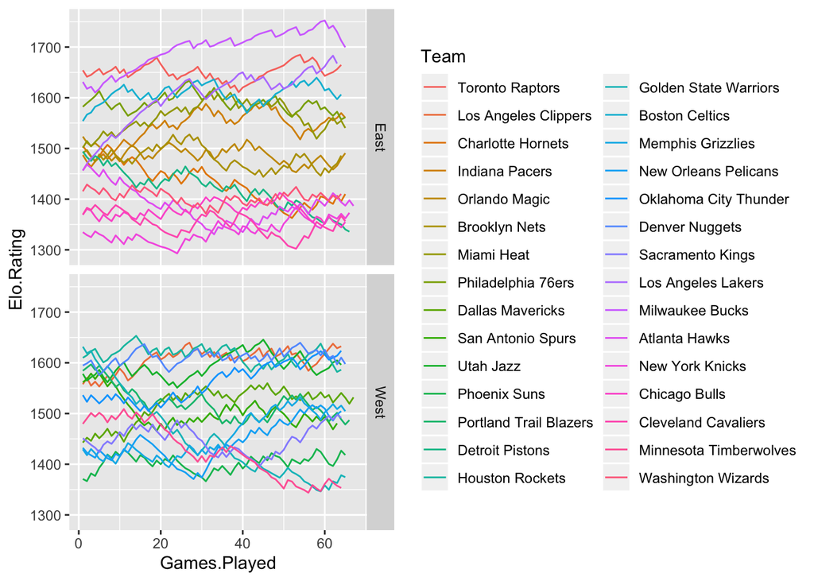

| Team | Elo Rating | Conference |
| --- | --- | --- |
| Toronto Raptors | 1664.7496 | East |
| Los Angeles Clippers | 1632.5429 | West |
| Charlotte Hornets | 1410.0369 | East |
| Indiana Pacers | 1560.5119 | East |
| Orlando Magic | 1490.6697 | East |
| Brooklyn Nets | 1485.9218 | East |
| Miami Heat | 1540.3984 | East |
| Philadelphia 76ers | 1561.4451 | East |
| Dallas Mavericks | 1531.9142 | West |
| San Antonio Spurs | 1480.6044 | West |

[output cut: 20 more lines]

### Simulations and Predictions

After calculating the Elo ratings for each NBA team up until the last game they played (before the season was suspended), we used these ratings to then perform simulations matching up teams based on the rest of the season schedule as well as the post-season tournaments based on the top seeded teams from the regular season.

[figure not shown]

##### The Remaining 2019-2020 Regular Season

Since the 2019-2020 season was cancelled before the end of the regular season, there were still more games to be played. Fortunately, we were able to scrape the remaining schedule that includes all the games that were supposed to happen for the rest of the regular season. The schedule looked something like so:

|  | id | visitor_team | home_team | time | tv | date |
| --- | --- | --- | --- | --- | --- | --- |
| 1 | 0 | Utah Jazz | Oklahoma City Thunder | 8:00 p.m. | NBA LP | 03-11-2020 |
| 2 | 1 | New Orleans Pelicans | Sacramento Kings | 10:00 p.m. | ESPN | 03-11-2020 |
| 3 | 2 | Chicago Bulls | Orlando Magic | 7:00 p.m. | NBA LP | 03-12-2020 |
| 4 | 3 | Boston Celtics | Milwaukee Bucks | 8:00 p.m. | TNT | 03-12-2020 |
| 5 | 4 | Memphis Grizzlies | Portland Trail Blazers | 10:00 p.m. | NBA LP | 03-12-2020 |
| 6 | 5 | Brooklyn Nets | Golden State Warriors | 10:30 p.m. | NBA LP | 03-12-2020 |

The regular season would have lasted all the way through April. Since we have all the matchups, we can run these teams through a simulation to compete based on probability using their elo ratings. This involved looping through the dataset, pulling each teams elo rating to calculate their probability of winning or losing, and then pulling a random sample as the winner. After the winner is found, the elo ratings are then updated to reflect this outcome.

To get an understanding of these results, we added the winners of each match to the dataframe next to each game.

|  | id | visitor_team | home_team | time | tv | date | winners |
| --- | --- | --- | --- | --- | --- | --- | --- |
| 1 | 0 | Utah Jazz | Oklahoma City Thunder | 8:00 p.m. | NBA LP | 03-11-2020 | Utah Jazz |
| 2 | 1 | New Orleans Pelicans | Sacramento Kings | 10:00 p.m. | ESPN | 03-11-2020 | Sacramento Kings |
| 3 | 2 | Chicago Bulls | Orlando Magic | 7:00 p.m. | NBA LP | 03-12-2020 | Chicago Bulls |
| 4 | 3 | Boston Celtics | Milwaukee Bucks | 8:00 p.m. | TNT | 03-12-2020 | Milwaukee Bucks |
| 5 | 4 | Memphis Grizzlies | Portland Trail Blazers | 10:00 p.m. | NBA LP | 03-12-2020 | Memphis Grizzlies |
| 6 | 5 | Brooklyn Nets | Golden State Warriors | 10:30 p.m. | NBA LP | 03-12-2020 | Golden State Warriors |

This finalized the regular season, resulting in the updated elo scores going into the playoffs.

|  | X | team | elo |
| --- | --- | --- | --- |
| 1 | 24 | Milwaukee Bucks | 1836.0666 |
| 2 | 23 | Los Angeles Lakers | 1772.8058 |
| 3 | 21 | Denver Nuggets | 1746.4027 |
| 4 | 11 | Utah Jazz | 1734.8849 |
| 5 | 2 | Los Angeles Clippers | 1731.3318 |
| 6 | 4 | Indiana Pacers | 1716.9334 |
| 7 | 1 | Toronto Raptors | 1675.1871 |
| 8 | 20 | Oklahoma City Thunder | 1662.4293 |
| 9 | 10 | San Antonio Spurs | 1644.1942 |
| 10 | 17 | Boston Celtics | 1639.6272 |

[output cut: 20 more lines]

##### The 2019-2020 NBA Playoffs

| team1 | team2 |
| --- | --- |
| Los Angeles Clippers | San Antonio Spurs |
| Los Angeles Lakers | Memphis Grizzlies |
| Utah Jazz | Houston Rockets |
| Denver Nuggets | Oklahoma City Thunder |
| Milwaukee Bucks | Charlotte Hornets |
| Toronto Raptors | Philadelphia 76ers |
| Indiana Pacers | Miami Heat |
| Boston Celtics | Orlando Magic |

The same process for the regular season was applied to these matchups with a couple of tweaks. For starters, this simulation was a best-of-7 tournament (as are all playoffs and finals matches). This means we had to simulate the games until a team reached 4 wins. The teams who won the right to advance to the second round are as follows:

```
## [1] "San Antonio Spurs"  "Los Angeles Lakers" "Utah Jazz"
## [4] "Denver Nuggets"     "Milwaukee Bucks"    "Toronto Raptors"
## [7] "Indiana Pacers"     "Orlando Magic"
```

The second round is the same process as the first round, except this time, the top 4 teams of each conference advance, meaning that the other 4 finish their season early. The second round is also known as the conference semifinals, that is, the winners of these games advance to their respective conference finals to compete for the conference title. The second round matchups are shown below:

| team1 | team2 |
| --- | --- |
| San Antonio Spurs | Los Angeles Lakers |
| Utah Jazz | Denver Nuggets |
| Milwaukee Bucks | Toronto Raptors |
| Indiana Pacers | Orlando Magic |

with the winners being:

```
## [1] "Los Angeles Lakers" "Denver Nuggets"     "Milwaukee Bucks"
## [4] "Indiana Pacers"
```

Again, these teams were put through a best-of-7 simulation, in whcih the following winners emerged:

```
## [1] "Los Angeles Lakers" "Milwaukee Bucks"
```

Finally, the NBA Finals. This is where the top winning teams from each conference (also the conference champions), compete head-to-head for the season. For our simu;ation, this turned out to be:

| team1 | team2 |
| --- | --- |
| Los Angeles Lakers | Milwaukee Bucks |

with the 2019-2020 NBA Champions being… *drum roll*…

```
## [1] "Los Angeles Lakers"
```

| X | team | elo |
| --- | --- | --- |
| 1 | Toronto Raptors | 1675.1871 |
| 2 | Los Angeles Clippers | 1731.3318 |
| 3 | Charlotte Hornets | 1555.5436 |
| 4 | Indiana Pacers | 1716.9334 |
| 5 | Orlando Magic | 1583.3484 |
| 6 | Brooklyn Nets | 1493.3178 |
| 7 | Miami Heat | 1568.0382 |
| 8 | Philadelphia 76ers | 1586.4259 |
| 9 | Dallas Mavericks | 1537.8001 |
| 10 | San Antonio Spurs | 1644.1942 |

[output cut: 20 more lines]

You can find visuals of how these elo ratings changed throughout this process in the results section of this report.

## Predicting the 2019-20 NBA Season Award Winners

Another interesting part of any NBA season is the awards given to the players and teams based on their regular season performances. Some key awards that catch headlines every year include Most Valuable Player (MVP) and Defensive Player of the Year (DPOY). In addition to predicting the end-of-season standings, we decided that any analysis of the remainder of the 2019-20 NBA season would be incomplete unless it discussed award winners in the major categories. As avid basketball fans, this idea resonated with us so we decided to scientifically predict who would ultimately win the MVP and DPOY awards.

In order to predict award winners at the end of the season, we needed to predict the leaders of some of the crucial statistical categories at the end of the season. To predict these players, we analyzed some significant statistics and identified the optimal regression model to predict these statistics. Some of the statistics we utilized in building this model include true shooting percentage (TS%), total rebound percentage (TRB%), assist percentage (AST%), and block percentage (BLK%) among 22 total recorded categories. For additional information on the exact statistics that were used in these predictions, refer to Table 3 (Appendix).

Accordingly, we examined different types of regression models in order to identify which type of model best predicted some of the major statistics. These include win shares (WS), value over replacement player (VORP), player efficiency rating (PER), usage percentage (USG%), offensive box plus/minus (OBPM), and defensive box plus/minus (DBPM). For more detailed explanations of the significance of each of these statistics, refer to Table 3 (Appendix).

To identify the best prediction model, we first predicted WS from the current 2019-20 season statistics using 4 different regression models: linear, lasso, ridge, and logistic. We measured the performance of every model with the actual WS values for each player using RMSE (root mean squared error) to determine which had the least error where smaller RMSE values indicated higher accuracy. In order to reduce Monte Carlo variability, we used 200 repeated random samples of the data for each model to find the true RMSE values.

We then used this to predict the MVP and DPOY by looking at the leaders at the end of the season in WS, VORP, PER, USG%, OBPM, and DBPM because these categories carried significant weighting in determing the respective awards. In order to produce statistics that would reflect the end-of-season data, we updated each player’s stats based on their team, position, schedule matchups, and usage percentage. We weighted each of these features by category and used the current player statistics to simulate the expected statistics for every player at the end of the 2019-20 season. We chose these specific features because a player’s team and schedule can heavily influence their output, the position they play directly affects which stats are affected, and their usage percentage indicates how heavily their team relies on that specific player (which correlates to more playing time). For example, a point guard is more likely to focus on assists, a shooting guard is more likely to focus on shooting percentage and 3-point attempt percentage, and a center is more likely to focus on rebounds and blocks. Similarly, a player with a high usage percentage will be instrumental to the team and will thus receive more playing time to add to their stat lines.

Another important note to consider is that some of the statistical categories are related to other categories. For example, offensive win shares (OWS) and defensive win shares (DWS) are directly related to overall win shares (WS) because they are simply more specific aspects of the general WS category. In order to account for these confounding variables and ensure that the predictions were accurately estimated from all of the relevant data, we made sure to exclude the respective confounding variables when running each regression model. For instance, we excluded BPM when running regression models on OBPM and DBPM for the same reason.

[output not shown]

[output not shown]

End-of-Season 2019-20 Predicted Stat Leaders with Logistic Regression Model

| Player | Predicted WS |
| --- | --- |
| Giannis Antetokounmpo | 13.877506 |
| James Harden | 12.972835 |
| Anthony Davis | 11.565551 |
| Damian Lillard | 11.113155 |
| LeBron James | 11.093538 |

| Player | Predicted VORP |
| --- | --- |
| Giannis Antetokounmpo | 6.1016776 |
| James Harden | 5.5020314 |
| LeBron James | 5.0603327 |
| Luka Dončić | 4.8621673 |
| Anthony Davis | 4.8286015 |

| Player | Predicted PER |
| --- | --- |
| Giannis Antetokounmpo | 31.185109 |
| James Harden | 27.727801 |
| Luka Dončić | 27.716629 |
| Anthony Davis | 27.368555 |
| Kawhi Leonard | 27.174260 |

| Player | Predicted USG% |
| --- | --- |
| James Harden | 37.275539 |
| Damian Lillard | 35.960337 |
| Giannis Antetokounmpo | 35.785494 |
| Luka Dončić | 35.376762 |
| Bradley Beal | 34.292230 |

| Player | Predicted OBPM |
| --- | --- |
| James Harden | 8.8743986 |
| Damian Lillard | 8.4481303 |
| Giannis Antetokounmpo | 7.5761856 |
| LeBron James | 7.2913535 |
| Luka Dončić | 7.2763925 |

| Player | Predicted DBPM |
| --- | --- |
| Giannis Antetokounmpo | 3.5744034 |
| Kris Dunn | 2.9169962 |
| Anthony Davis | 2.9095432 |
| Nikola Jokić | 2.7774419 |
| Bam Adebayo | 2.5586346 |

# Results

A summary of the results of the simulation can be found below in the order of First Round Playoffs (top 8 teams from both conferences), Second Round Playoffs (top 4 teams from each conference), Third Round Playoffs (The conference finals), then the NBA Finals which produces the Seasons Champion. This will show who played, then who, out of those teams, won the right to move forward.

| team1 | team2 |
| --- | --- |
| Los Angeles Clippers | San Antonio Spurs |
| Los Angeles Lakers | Memphis Grizzlies |
| Utah Jazz | Houston Rockets |
| Denver Nuggets | Oklahoma City Thunder |
| Milwaukee Bucks | Charlotte Hornets |
| Toronto Raptors | Philadelphia 76ers |
| Indiana Pacers | Miami Heat |
| Boston Celtics | Orlando Magic |

```
## [1] "San Antonio Spurs"  "Los Angeles Lakers" "Utah Jazz"
## [4] "Denver Nuggets"     "Milwaukee Bucks"    "Toronto Raptors"
## [7] "Indiana Pacers"     "Orlando Magic"
```

| team1 | team2 |
| --- | --- |
| San Antonio Spurs | Los Angeles Lakers |
| Utah Jazz | Denver Nuggets |
| Milwaukee Bucks | Toronto Raptors |
| Indiana Pacers | Orlando Magic |

```
## [1] "Los Angeles Lakers" "Denver Nuggets"     "Milwaukee Bucks"
## [4] "Indiana Pacers"
```

| team1 | team2 |
| --- | --- |
| Los Angeles Lakers | Denver Nuggets |
| Milwaukee Bucks | Indiana Pacers |

```
## [1] "Los Angeles Lakers" "Milwaukee Bucks"
```

| team1 | team2 |
| --- | --- |
| Los Angeles Lakers | Milwaukee Bucks |

```
## [1] "Los Angeles Lakers"
```

The plot below shows how the Elo Ratings for each NBA team changed throughout the end of the regular season, as well as both the playoffs and finals. A line that remains flat for a short period of time represetns the Elo Rating reamining constant due to the fact of not playing at that instance. The changes come after they have played a game.

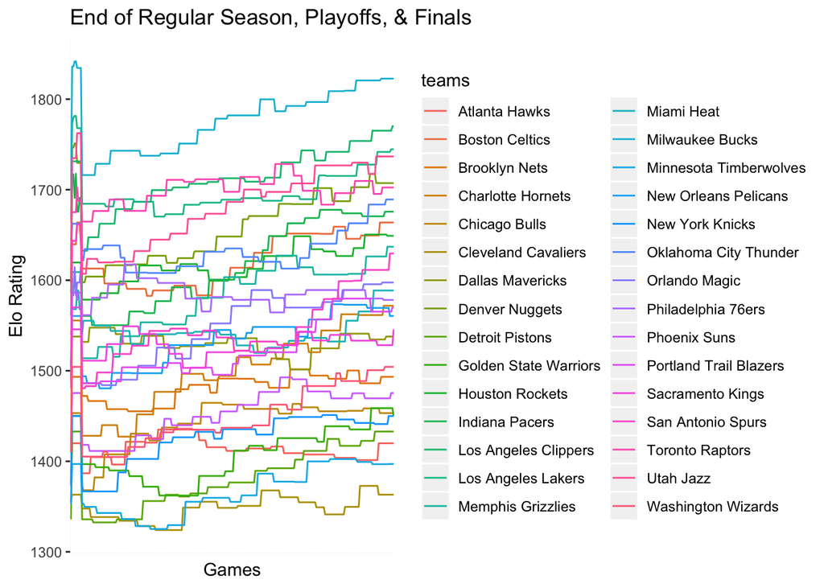

In addition to simulating how the 2019-20 NBA season and Playoffs would have ended, we tested several regression models to determine the best model to predict end-of-season WS. By testing linear, lasso, ridge, and logistic regression models, found that the lasso model provided the lowest RMSE value (0.26174868) with the linear model (0.34356328) and logistic models (0.34614456) providing slightly higher RMSE values.

Using these accumulated season statistics, we determined the end-of-season statistics by updating each players’ stat lines based on team, position, schedule matchups, and usage percentage stats as explained in detail in the Methods section.

The final season stat leaders for each of the categories is shown in Table 2. We verified these predictions by limiting the qualifiers for each category and comparing with each player’s previous performance history. We narrowed the pool of players down by only considering players with more than 25 games played and 1200 minutes played because this reflects the criteria that the NBA Season Awards use to nominate qualifying players. By inspecting the top five players in each category, we noticed several household names and early season favorites for MVP and DPOY including Giannis Antetokounmpo, James Harden, LeBron James, and Anthony Davis.

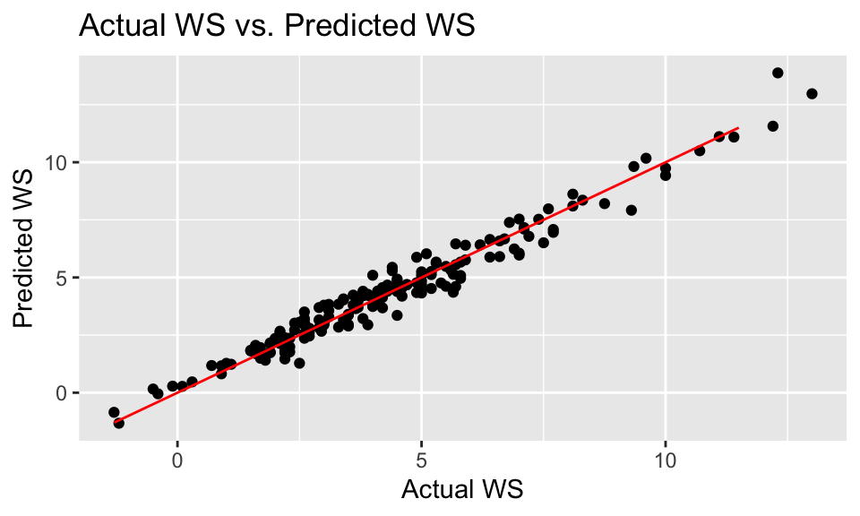

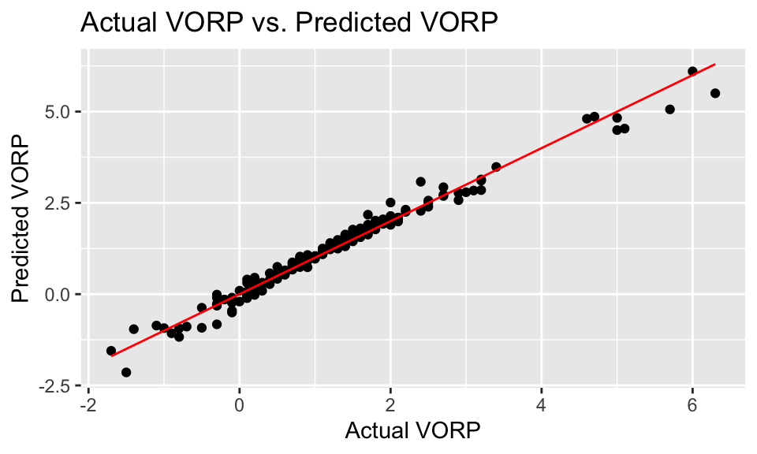

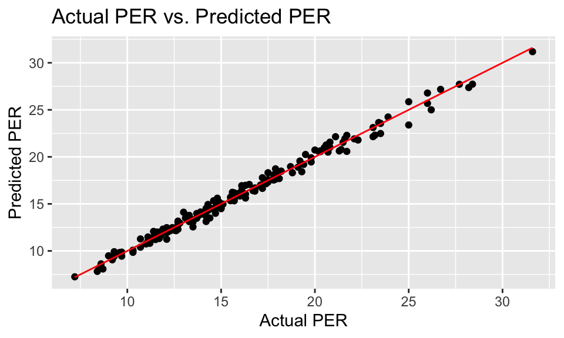

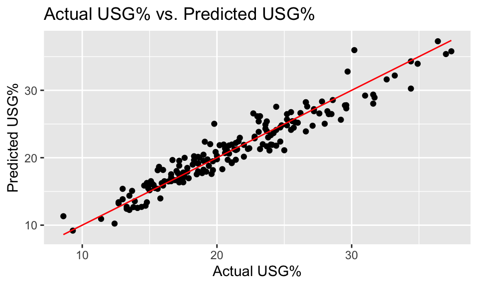

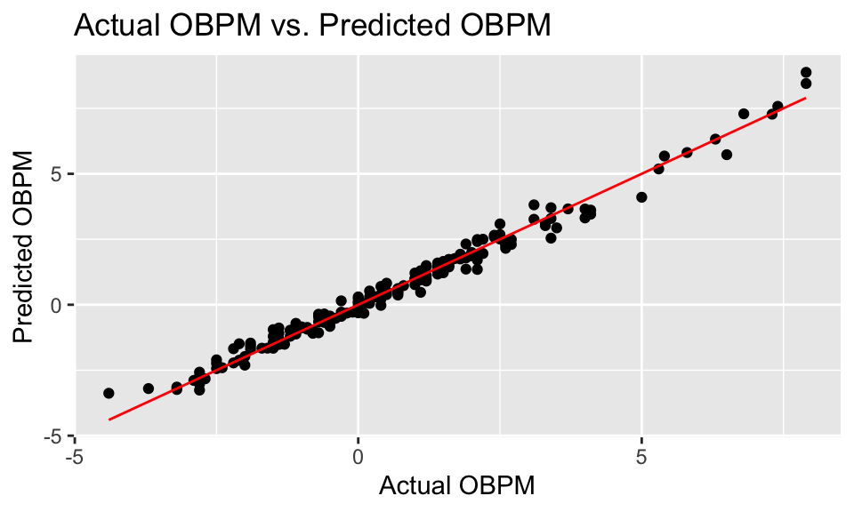

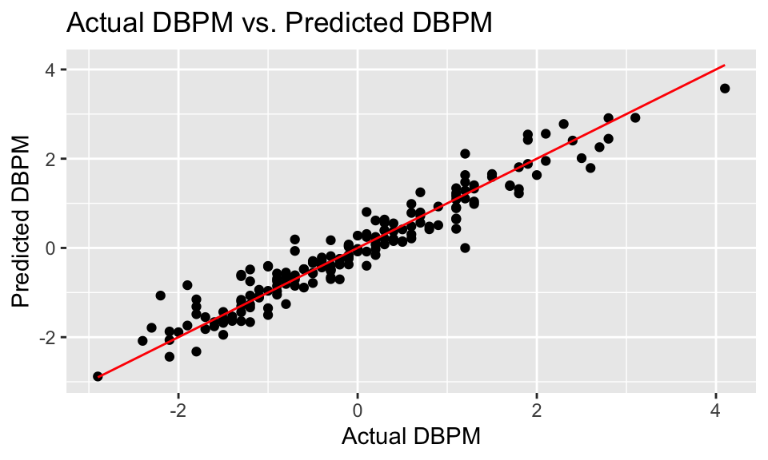

Predictions of Key Statistics with Logistic Regression Model

# Conclusion

Congratulations to the Los Angeles Lakers on hypothetically winning the 2019-2020 NBA season, There were many great teams this year with a lot of tough matchups. Unfortunately, this year it was not the Houston Rockets.

## Drawbacks of the Elo Rating Predictions

Although elo ratings are simple and intuitive, this is both a blessing and a curse. Given the performance, ELo Rating should be commended, however, this does not mean it should be used to support that addictive sports gambling habit of yours. This method is designed to be effective despite its simplicity. This model does not account for roster changes, injusry updates, or individual player performance as most sports prediction models should. It evaluates the teams as a whole, solely based on win/loss, margin of victory, and home court advantage. Also, the simulations are random, based on a teams probability of winning. This means the results could vary each time you run it, which requires running it a reasonable amount of times (ast least 100) in order to get meaningful results. The results produced above are based on the simulation that ran when this document was created. However, after running it multiple times, the consistent winner of the 2019-2020 season proved to be the Los Angeles Lakers (RIP Kobe Bryant). This can be done by wrapping the script in a do loop that runs it 100 times while keeping track of the winner each season, and counting each teams wins to find who won most often. This method was used to get the result for the Los Angeles Lakers, but is not shown within this report.

# Appendix

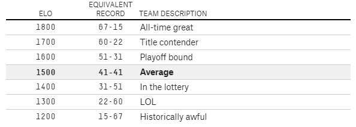

Breakdown of Elo Rating

| Statistics | Meaning |
| --- | --- |
| G | Num. games played |
| MP | Num. minutes played |
| PER | Measure of per-minute production |
| TS. | Overall shooting efficiency |
| X3PAr | % of field goal attempts from 3-point range |
| FTr | Num. free throw attempts per field goal attempt |
| ORB. | % of available offensive rebounds that a player grabbed |
| DRB. | % of available defensive rebounds that a player grabbed |
| TRB. | % of available total rebounds that a player grabbed |
| AST. | % of teammate field goals that a player assisted |
| STL. | % of opponent possessions that were stolen by a player |
| BLK. | % of opponent field goals attempts that were blocked by a player |
| TOV. | Num. turnovers committed per 100 plays |
| USG. | % of team plays used by a player |
| OWS | Num. wins contributed by a player from his offense |
| DWS | Num. wins contributed by a player from his defense |
| WS | Num. wins contributed by a player |
| WS.48 | Num. wins contributed by a player per 48 minutes |
| OBPM | Offensive points per 100 possessions above a league-average player |
| DBPM | Defensive points per 100 possessions above a league-average player |
| BPM | Total points per 100 possessions above a league-average player |
| VORP | Points per 100 team possessions contributed by a player above a replacement-level player |

# References

> [1] List of all sporting events canceled around the world during the coronavirus pandemic (https://www.espn.com/olympics/story/_/id/28824781/list-sporting-events-canceled-coronavirus)

> [2] Elo ratings system (https://en.wikipedia.org/wiki/Elo_rating_system)

> [3] FiveThirtyEight NBA Elo Ratings (https://fivethirtyeight.com/features/how-we-calculate-nba-elo-ratings/)

> [4] Compilation of in-depth NBA statistics (https://www.basketball-reference.com/)

> [5] Elo Ratings for NBA Teams (http://practicallypredictable.com/2018/04/15/elo-ratings-for-nba-teams/#more-1019)